# Reproducible Research: Peer Assessment 1

https://github.com/rwgeorge/RepData_PeerAssessment1

04/19/2015

## Introduction

##### (Provided with Assignment)

It is now possible to collect a large amount of data about personal movement using activity monitoring devices such as a [Fitbit](http://www.fitbit.com), [Nike Fuelband](http://www.nike.com/us/en_us/c/nikeplus-fuelband), or [Jawbone Up](https://jawbone.com/up). These type of devices are part of the “quantified self” movement – a group of enthusiasts who take measurements about themselves regularly to improve their health, to find patterns in their behavior, or because they are tech geeks. But these data remain under-utilized both because the raw data are hard to obtain and there is a lack of statistical methods and software for processing and interpreting the data.

This assignment makes use of data from a personal activity monitoring device. This device collects data at 5 minute intervals through out the day. The data consists of two months of data from an anonymous individual collected during the months of October and November, 2012 and include the number of steps taken in 5 minute intervals each day.

## Basic Setup

#### Libraries

This assignment solution makes use of the following R packages:

- **knitr**: Used to “knit” this R Markdown file
- **dplyr**: Used for general data set manipulation
- **lubridate**: Used to make working with dates and times easy
- **ggplot2**: used for plotting

```r
library("knitr")
library("dplyr")
library("lubridate")
library("ggplot2")
```

#### Directories

The figures for this assignment are stored in the the **figure/** directory at the root of the working directory.

```r
opts_chunk$set(echo = TRUE, results = "hide", fig.path = "figure/")
```

## Data

##### (Provided with Assignment)

The data for this assignment has been included as part of the Github fork created, but it still can be downloaded from the course web site.

If you wish to download the data, go here:

- Dataset: [Activity monitoring data](https://d396qusza40orc.cloudfront.net/repdata%2Fdata%2Factivity.zip) [52K]

The variables included in this dataset are:

- **steps**: Number of steps taking in a 5-minute interval (missing values are coded as `NA`)
- **date**: The date on which the measurement was taken in `YYYY-MM-DD` format
- **interval**: Identifier for the 5-minute interval in which measurement was taken

The dataset is stored in a comma-separated-value (CSV) file and there are a total of **17,568** observations in this dataset.

### Loading & Preprocessing the Data

The data needs to be in the working directory for the R code to run properly. This is automatic if the Github fork was used. If the data is not in the working directory, the script will attempt to download it.

#### Download the Data

```r
fileLocation <- "https://d396qusza40orc.cloudfront.net/repdata%2Fdata%2Factivity.zip"
fileName <- "activity.zip"
if (!file.exists(fileName))
  download.file(fileLocation, fileName, method = "curl")

fileDate <- format(file.info(fileName)$mtime, "%B %d, %Y at %H:%M:%S")
```

**activity.zip** obtained on **April 19, 2015 at 13:02:17**.

#### Unzip Data

##### (making sure data file used actually comes form the archive)

```r
unzip(fileName)
```

#### Read Raw Data

```r
rawData <- read.csv("activity.csv", na.strings = "NA")
```

#### Preprocess Raw Data

```r
preprocessedData <- tbl_df(rawData)
preprocessedData <- mutate(preprocessedData, date = ymd(date))
```

## What is mean total number of steps taken per day?

Mising values were ignored in the preprocessed data set. The data was then grouped by date and summarized by adding all of the steps taken.

#### Determine Number of Steps Per Day

```r
stepsPerDay <- na.omit(preprocessedData)
stepsPerDay <- group_by(stepsPerDay, date)
stepsPerDay <- summarise(stepsPerDay, steps = sum(steps))
```

The mean and median number of steps per day was calculated.

#### Mean & Median Steps Per Day

```r
meanSteps <- mean(stepsPerDay$steps)
medianSteps <- median(stepsPerDay$steps)
```

##### Total Steps Per Day Stats

- Mean = 10766
- Median = 10765

#### Steps Per Day Histogram

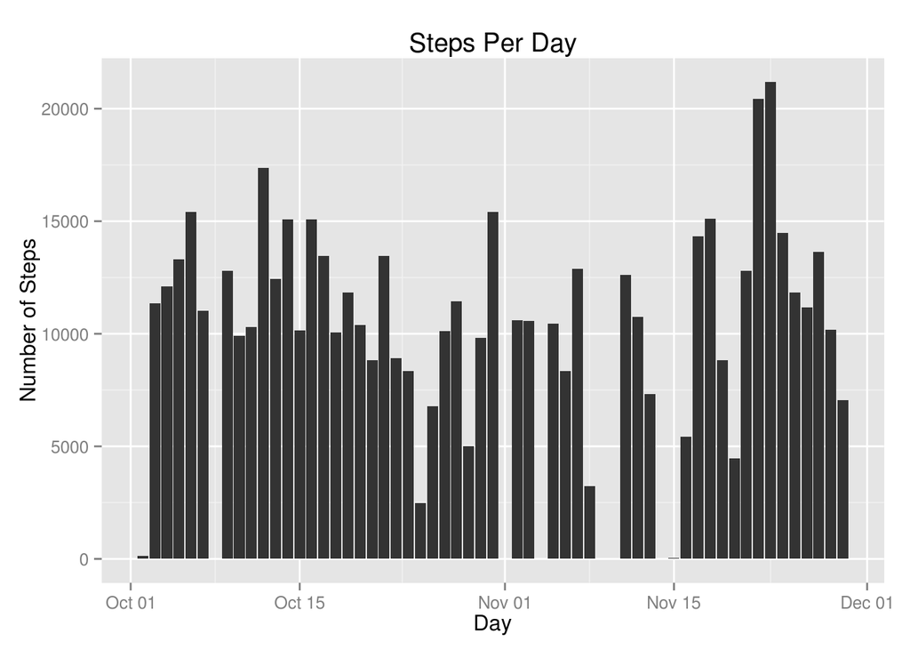

```r
ggplot(stepsPerDay, aes(date)) + ggtitle("Steps Per Day") + geom_histogram(stat = "identity", aes(y = steps)) + xlab("Day") + ylab("Number of Steps")
```

## What is the average daily activity pattern?

```r
averageStepsPerInterval <- na.omit(preprocessedData)
averageStepsPerInterval <- group_by(averageStepsPerInterval, interval)
summarise(averageStepsPerInterval, steps = mean(steps))
```

#### Determine Max Interval

```r
maxInterval <- averageStepsPerInterval$interval[which.max(averageStepsPerInterval$steps)]
```

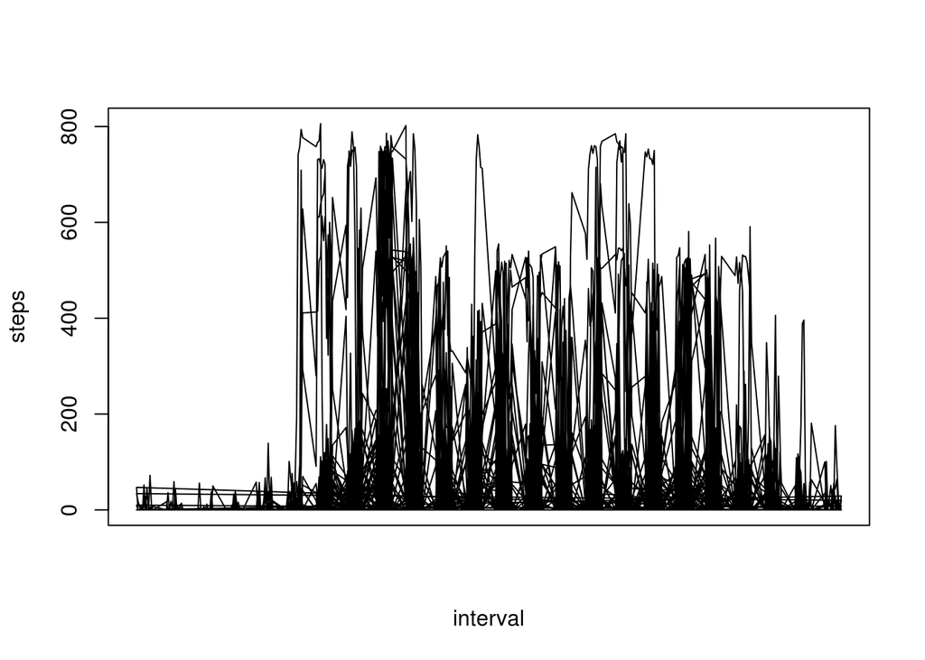

```r
with(averageStepsPerInterval, {plot(interval, steps, type = "l", xaxt = "n")})
```

## Inputing Missing Values

Note that there are a number of days/intervals where there are missing values (coded as `NA`). The presence of missing days may introduce bias into some calculations or summaries of the data.

#### Count Missing Values

```r
missingValues <- sum(is.na(preprocessedData))
```

There were 2304 in the data set.

#### Replace Missing Values

```r
resultData <- preprocessedData

naIndices <- which(is.na(resultData$steps), arr.ind = TRUE)
count <- length(naIndices)
for (i in 1 : count) {
  resultData$steps[naIndices[i]] <- averageStepsPerInterval$steps[averageStepsPerInterval$interval == resultData$interval[naIndices[i]]]
}
```

```
## Warning in resultData$steps[naIndices[i]] <-
## averageStepsPerInterval$steps[averageStepsPerInterval$interval == : number
## of items to replace is not a multiple of replacement length
```

[output not shown]

[output not shown]

```r
resultData <- group_by(resultData, date)
resultData <- summarise(resultData, steps = sum(steps))
```

There was a problem in the replacement as can be seen by the warnings.

#### Determine New Averages

```r
newAverageStepsPerDay <- mean(resultData$steps)
newMedianStepsPerDay <- median(resultData$steps)
```

The new averages for replaced values were as follows: * Mean = 9370 * Median = 10395

#### Plot of Total Number of Steps Taken Each Day

##### (with replaced data)

Histogram of the total number of steps taken each day:

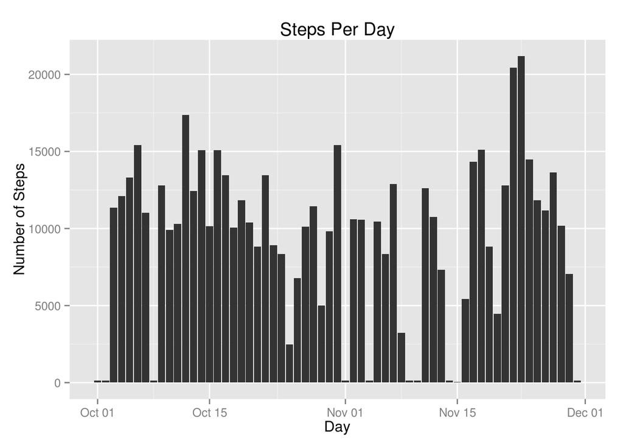

```r
ggplot(resultData, aes(date)) + ggtitle("Steps Per Day") + geom_histogram(stat = "identity", aes(y = steps)) + xlab("Day") + ylab("Number of Steps")
```

```r
days <- resultData
days <- mutate(days, weekday = ifelse(weekdays(date) != "Saturday" & weekdays(date) != "Sunday", "weekday", "weekend"))
```